# Risk Factor Analysis

## Outcome Variable

**Outcome Variable:** wast_rec90d

## Predictor Variables

**Intervention Variable:** exclfeed3

**Adjustment Set:**

unadjusted

## Stratifying Variables

The analysis was stratified on these variable(s):

- agecat
- studyid
- country

## Data Summary

| agecat | studyid | country | exclfeed3 | wast_rec90d | n_cell | n | outcome_variable |
| --- | --- | --- | --- | --- | --- | --- | --- |
| 0-24 months | ki0047075b-MAL-ED | BANGLADESH | 1 | 0 | 26 | 117 | wast_rec90d |
| 0-24 months | ki0047075b-MAL-ED | BANGLADESH | 1 | 1 | 51 | 117 | wast_rec90d |
| 0-24 months | ki0047075b-MAL-ED | BANGLADESH | 0 | 0 | 15 | 117 | wast_rec90d |
| 0-24 months | ki0047075b-MAL-ED | BANGLADESH | 0 | 1 | 25 | 117 | wast_rec90d |
| 0-24 months | ki0047075b-MAL-ED | BRAZIL | 1 | 0 | 4 | 22 | wast_rec90d |
| 0-24 months | ki0047075b-MAL-ED | BRAZIL | 1 | 1 | 5 | 22 | wast_rec90d |
| 0-24 months | ki0047075b-MAL-ED | BRAZIL | 0 | 0 | 2 | 22 | wast_rec90d |
| 0-24 months | ki0047075b-MAL-ED | BRAZIL | 0 | 1 | 11 | 22 | wast_rec90d |
| 0-24 months | ki0047075b-MAL-ED | INDIA | 1 | 0 | 27 | 162 | wast_rec90d |
| 0-24 months | ki0047075b-MAL-ED | INDIA | 1 | 1 | 51 | 162 | wast_rec90d |
| 0-24 months | ki0047075b-MAL-ED | INDIA | 0 | 0 | 35 | 162 | wast_rec90d |
| 0-24 months | ki0047075b-MAL-ED | INDIA | 0 | 1 | 49 | 162 | wast_rec90d |
| 0-24 months | ki0047075b-MAL-ED | NEPAL | 1 | 0 | 6 | 96 | wast_rec90d |
| 0-24 months | ki0047075b-MAL-ED | NEPAL | 1 | 1 | 16 | 96 | wast_rec90d |
| 0-24 months | ki0047075b-MAL-ED | NEPAL | 0 | 0 | 14 | 96 | wast_rec90d |
| 0-24 months | ki0047075b-MAL-ED | NEPAL | 0 | 1 | 60 | 96 | wast_rec90d |
| 0-24 months | ki0047075b-MAL-ED | PERU | 1 | 0 | 1 | 33 | wast_rec90d |
| 0-24 months | ki0047075b-MAL-ED | PERU | 1 | 1 | 3 | 33 | wast_rec90d |
| 0-24 months | ki0047075b-MAL-ED | PERU | 0 | 0 | 5 | 33 | wast_rec90d |
| 0-24 months | ki0047075b-MAL-ED | PERU | 0 | 1 | 24 | 33 | wast_rec90d |
| 0-24 months | ki0047075b-MAL-ED | SOUTH AFRICA | 1 | 0 | 0 | 77 | wast_rec90d |
| 0-24 months | ki0047075b-MAL-ED | SOUTH AFRICA | 1 | 1 | 2 | 77 | wast_rec90d |
| 0-24 months | ki0047075b-MAL-ED | SOUTH AFRICA | 0 | 0 | 12 | 77 | wast_rec90d |
| 0-24 months | ki0047075b-MAL-ED | SOUTH AFRICA | 0 | 1 | 63 | 77 | wast_rec90d |
| 0-24 months | ki0047075b-MAL-ED | TANZANIA, UNITED REPUBLIC OF | 1 | 0 | 1 | 44 | wast_rec90d |
| 0-24 months | ki0047075b-MAL-ED | TANZANIA, UNITED REPUBLIC OF | 1 | 1 | 7 | 44 | wast_rec90d |
| 0-24 months | ki0047075b-MAL-ED | TANZANIA, UNITED REPUBLIC OF | 0 | 0 | 7 | 44 | wast_rec90d |
| 0-24 months | ki0047075b-MAL-ED | TANZANIA, UNITED REPUBLIC OF | 0 | 1 | 29 | 44 | wast_rec90d |
| 0-24 months | ki1000108-CMC-V-BCS-2002 | INDIA | 1 | 0 | 5 | 11 | wast_rec90d |
| 0-24 months | ki1000108-CMC-V-BCS-2002 | INDIA | 1 | 1 | 6 | 11 | wast_rec90d |

[output cut: 162 more lines]

The following strata were considered:

- agecat: 0-24 months, studyid: ki0047075b-MAL-ED, country: BANGLADESH
- agecat: 0-24 months, studyid: ki0047075b-MAL-ED, country: BRAZIL
- agecat: 0-24 months, studyid: ki0047075b-MAL-ED, country: INDIA
- agecat: 0-24 months, studyid: ki0047075b-MAL-ED, country: NEPAL
- agecat: 0-24 months, studyid: ki0047075b-MAL-ED, country: PERU
- agecat: 0-24 months, studyid: ki0047075b-MAL-ED, country: SOUTH AFRICA
- agecat: 0-24 months, studyid: ki0047075b-MAL-ED, country: TANZANIA, UNITED REPUBLIC OF
- agecat: 0-24 months, studyid: ki1000108-CMC-V-BCS-2002, country: INDIA
- agecat: 0-24 months, studyid: ki1000108-IRC, country: INDIA
- agecat: 0-24 months, studyid: ki1000109-EE, country: PAKISTAN
- agecat: 0-24 months, studyid: ki1000304b-SAS-CompFeed, country: INDIA
- agecat: 0-24 months, studyid: ki1017093b-PROVIDE, country: BANGLADESH
- agecat: 0-24 months, studyid: ki1101329-Keneba, country: GAMBIA
- agecat: 0-24 months, studyid: ki1113344-GMS-Nepal, country: NEPAL
- agecat: 0-24 months, studyid: kiGH5241-JiVitA-3, country: BANGLADESH
- agecat: 0-24 months, studyid: kiGH5241-JiVitA-4, country: BANGLADESH
- agecat: 0-6 months, studyid: ki0047075b-MAL-ED, country: BANGLADESH
- agecat: 0-6 months, studyid: ki0047075b-MAL-ED, country: BRAZIL
- agecat: 0-6 months, studyid: ki0047075b-MAL-ED, country: INDIA
- agecat: 0-6 months, studyid: ki0047075b-MAL-ED, country: NEPAL
- agecat: 0-6 months, studyid: ki0047075b-MAL-ED, country: PERU
- agecat: 0-6 months, studyid: ki0047075b-MAL-ED, country: SOUTH AFRICA
- agecat: 0-6 months, studyid: ki0047075b-MAL-ED, country: TANZANIA, UNITED REPUBLIC OF
- agecat: 0-6 months, studyid: ki1000108-CMC-V-BCS-2002, country: INDIA
- agecat: 0-6 months, studyid: ki1000108-IRC, country: INDIA
- agecat: 0-6 months, studyid: ki1000109-EE, country: PAKISTAN
- agecat: 0-6 months, studyid: ki1000304b-SAS-CompFeed, country: INDIA
- agecat: 0-6 months, studyid: ki1017093b-PROVIDE, country: BANGLADESH
- agecat: 0-6 months, studyid: ki1101329-Keneba, country: GAMBIA
- agecat: 0-6 months, studyid: ki1113344-GMS-Nepal, country: NEPAL
- agecat: 0-6 months, studyid: kiGH5241-JiVitA-3, country: BANGLADESH
- agecat: 0-6 months, studyid: kiGH5241-JiVitA-4, country: BANGLADESH
- agecat: 6-24 months, studyid: ki0047075b-MAL-ED, country: BANGLADESH
- agecat: 6-24 months, studyid: ki0047075b-MAL-ED, country: BRAZIL
- agecat: 6-24 months, studyid: ki0047075b-MAL-ED, country: INDIA
- agecat: 6-24 months, studyid: ki0047075b-MAL-ED, country: NEPAL
- agecat: 6-24 months, studyid: ki0047075b-MAL-ED, country: PERU
- agecat: 6-24 months, studyid: ki0047075b-MAL-ED, country: SOUTH AFRICA
- agecat: 6-24 months, studyid: ki0047075b-MAL-ED, country: TANZANIA, UNITED REPUBLIC OF
- agecat: 6-24 months, studyid: ki1000108-CMC-V-BCS-2002, country: INDIA
- agecat: 6-24 months, studyid: ki1000108-IRC, country: INDIA
- agecat: 6-24 months, studyid: ki1000109-EE, country: PAKISTAN
- agecat: 6-24 months, studyid: ki1000304b-SAS-CompFeed, country: INDIA
- agecat: 6-24 months, studyid: ki1017093b-PROVIDE, country: BANGLADESH
- agecat: 6-24 months, studyid: ki1101329-Keneba, country: GAMBIA
- agecat: 6-24 months, studyid: ki1113344-GMS-Nepal, country: NEPAL
- agecat: 6-24 months, studyid: kiGH5241-JiVitA-3, country: BANGLADESH
- agecat: 6-24 months, studyid: kiGH5241-JiVitA-4, country: BANGLADESH

### Dropped Strata

Some strata were dropped due to rare outcomes:

- agecat: 0-24 months, studyid: ki0047075b-MAL-ED, country: BRAZIL
- agecat: 0-24 months, studyid: ki0047075b-MAL-ED, country: PERU
- agecat: 0-24 months, studyid: ki0047075b-MAL-ED, country: SOUTH AFRICA
- agecat: 0-24 months, studyid: ki0047075b-MAL-ED, country: TANZANIA, UNITED REPUBLIC OF
- agecat: 0-24 months, studyid: ki1000108-CMC-V-BCS-2002, country: INDIA
- agecat: 0-24 months, studyid: ki1000108-IRC, country: INDIA
- agecat: 0-24 months, studyid: ki1000109-EE, country: PAKISTAN
- agecat: 0-24 months, studyid: kiGH5241-JiVitA-4, country: BANGLADESH
- agecat: 0-6 months, studyid: ki0047075b-MAL-ED, country: BRAZIL
- agecat: 0-6 months, studyid: ki0047075b-MAL-ED, country: NEPAL
- agecat: 0-6 months, studyid: ki0047075b-MAL-ED, country: PERU
- agecat: 0-6 months, studyid: ki0047075b-MAL-ED, country: SOUTH AFRICA
- agecat: 0-6 months, studyid: ki0047075b-MAL-ED, country: TANZANIA, UNITED REPUBLIC OF
- agecat: 0-6 months, studyid: ki1000108-CMC-V-BCS-2002, country: INDIA
- agecat: 0-6 months, studyid: ki1000108-IRC, country: INDIA
- agecat: 0-6 months, studyid: ki1000109-EE, country: PAKISTAN
- agecat: 0-6 months, studyid: ki1000304b-SAS-CompFeed, country: INDIA
- agecat: 0-6 months, studyid: kiGH5241-JiVitA-4, country: BANGLADESH
- agecat: 6-24 months, studyid: ki0047075b-MAL-ED, country: BRAZIL
- agecat: 6-24 months, studyid: ki0047075b-MAL-ED, country: NEPAL
- agecat: 6-24 months, studyid: ki0047075b-MAL-ED, country: PERU
- agecat: 6-24 months, studyid: ki0047075b-MAL-ED, country: SOUTH AFRICA
- agecat: 6-24 months, studyid: ki0047075b-MAL-ED, country: TANZANIA, UNITED REPUBLIC OF
- agecat: 6-24 months, studyid: ki1000108-CMC-V-BCS-2002, country: INDIA
- agecat: 6-24 months, studyid: ki1000108-IRC, country: INDIA
- agecat: 6-24 months, studyid: ki1000109-EE, country: PAKISTAN
- agecat: 6-24 months, studyid: ki1000304b-SAS-CompFeed, country: INDIA
- agecat: 6-24 months, studyid: kiGH5241-JiVitA-3, country: BANGLADESH
- agecat: 6-24 months, studyid: kiGH5241-JiVitA-4, country: BANGLADESH

## Methods Detail

We’re interested in the causal parameters $E[Y_a]$ for all values of $a \in \mathcal{A}$. These parameters represent the mean outcome if, possibly contrary to fact, we intervened to set all units to have $A=a$. Under the randomization and positivity assumptions, these are identified by the statistical parameters $\psi_a=E_W[E_{Y|A,W}(Y|A=a,W)]$. In addition, we’re interested in the mean of $Y$, $E[Y]$ under no intervention (the observed mean). We will estimate these parameters by using SuperLearner to fit the relevant likelihood factors – $E_{Y|A,W}(Y|A=a,W)$ and $p(A=a|W)$, and then updating our likelihood fit using a joint TMLE.

For unadjusted analyses ($W=\{\}$), initial likelihoods were estimated using Lrnr_glm to estimate the simple $E(Y|A)$ and Lrnr_mean to estimate $p(A)$. For adjusted analyses, a small library containing Lrnr_glmnet, Lrnr_xgboost, and Lrnr_mean was used.

Having estimated these parameters, we will then use the delta method to estimate relative risks and attributable risks relative to a prespecified baseline level of $A$.

# Results Detail

## Results Plots

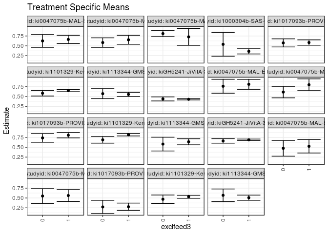

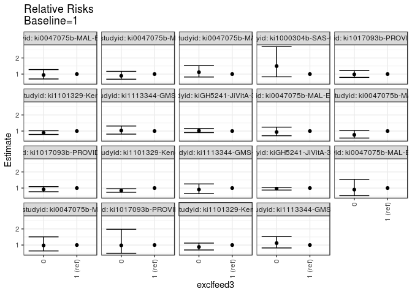

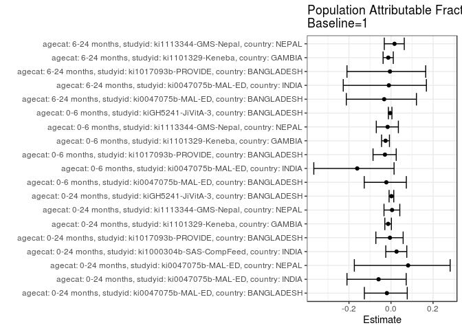

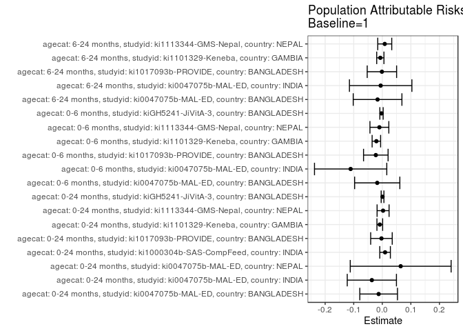

## Results Table

### Parameter: TSM

| agecat | studyid | country | intervention_level | baseline_level | estimate | ci_lower | ci_upper |
| --- | --- | --- | --- | --- | --- | --- | --- |
| 0-24 months | ki0047075b-MAL-ED | BANGLADESH | 1 | NA | 0.6623377 | 0.5572479 | 0.7674274 |
| 0-24 months | ki0047075b-MAL-ED | BANGLADESH | 0 | NA | 0.6250000 | 0.4630597 | 0.7869403 |
| 0-24 months | ki0047075b-MAL-ED | INDIA | 1 | NA | 0.6538462 | 0.5405099 | 0.7671825 |
| 0-24 months | ki0047075b-MAL-ED | INDIA | 0 | NA | 0.5833333 | 0.4629520 | 0.7037146 |
| 0-24 months | ki0047075b-MAL-ED | NEPAL | 1 | NA | 0.7272727 | 0.5132170 | 0.9413285 |
| 0-24 months | ki0047075b-MAL-ED | NEPAL | 0 | NA | 0.8108108 | 0.7343861 | 0.8872355 |
| 0-24 months | ki1000304b-SAS-CompFeed | INDIA | 1 | NA | 0.3600000 | 0.2937351 | 0.4262649 |
| 0-24 months | ki1000304b-SAS-CompFeed | INDIA | 0 | NA | 0.5384615 | 0.2364546 | 0.8404685 |
| 0-24 months | ki1017093b-PROVIDE | BANGLADESH | 1 | NA | 0.5841121 | 0.5162835 | 0.6519408 |
| 0-24 months | ki1017093b-PROVIDE | BANGLADESH | 0 | NA | 0.5744681 | 0.4711895 | 0.6777467 |
| 0-24 months | ki1101329-Keneba | GAMBIA | 1 | NA | 0.6505747 | 0.6230042 | 0.6781452 |
| 0-24 months | ki1101329-Keneba | GAMBIA | 0 | NA | 0.5837563 | 0.5129698 | 0.6545429 |
| 0-24 months | ki1113344-GMS-Nepal | NEPAL | 1 | NA | 0.5552885 | 0.5025632 | 0.6080137 |
| 0-24 months | ki1113344-GMS-Nepal | NEPAL | 0 | NA | 0.5733333 | 0.4464146 | 0.7002520 |
| 0-24 months | kiGH5241-JiVitA-3 | BANGLADESH | 1 | NA | 0.4299823 | 0.4145969 | 0.4453677 |
| 0-24 months | kiGH5241-JiVitA-3 | BANGLADESH | 0 | NA | 0.4398977 | 0.3888990 | 0.4908964 |
| 0-6 months | ki0047075b-MAL-ED | BANGLADESH | 1 | NA | 0.8108108 | 0.6837788 | 0.9378428 |
| 0-6 months | ki0047075b-MAL-ED | BANGLADESH | 0 | NA | 0.7619048 | 0.5846570 | 0.9391525 |
| 0-6 months | ki0047075b-MAL-ED | INDIA | 1 | NA | 0.8000000 | 0.6503909 | 0.9496091 |
| 0-6 months | ki0047075b-MAL-ED | INDIA | 0 | NA | 0.6136364 | 0.4674979 | 0.7597749 |
| 0-6 months | ki1017093b-PROVIDE | BANGLADESH | 1 | NA | 0.8064516 | 0.7385486 | 0.8743546 |
| 0-6 months | ki1017093b-PROVIDE | BANGLADESH | 0 | NA | 0.7377049 | 0.6272659 | 0.8481439 |
| 0-6 months | ki1101329-Keneba | GAMBIA | 1 | NA | 0.8191882 | 0.7875753 | 0.8508011 |
| 0-6 months | ki1101329-Keneba | GAMBIA | 0 | NA | 0.6893204 | 0.6043821 | 0.7742587 |
| 0-6 months | ki1113344-GMS-Nepal | NEPAL | 1 | NA | 0.6400000 | 0.5624099 | 0.7175901 |
| 0-6 months | ki1113344-GMS-Nepal | NEPAL | 0 | NA | 0.5806452 | 0.4056011 | 0.7556893 |
| 0-6 months | kiGH5241-JiVitA-3 | BANGLADESH | 1 | NA | 0.6902439 | 0.6719683 | 0.7085195 |
| 0-6 months | kiGH5241-JiVitA-3 | BANGLADESH | 0 | NA | 0.6615385 | 0.6040112 | 0.7190657 |
| 6-24 months | ki0047075b-MAL-ED | BANGLADESH | 1 | NA | 0.5250000 | 0.3534413 | 0.6965587 |
| 6-24 months | ki0047075b-MAL-ED | BANGLADESH | 0 | NA | 0.4736842 | 0.2738216 | 0.6735468 |
| 6-24 months | ki0047075b-MAL-ED | INDIA | 1 | NA | 0.5625000 | 0.4116867 | 0.7133133 |
| 6-24 months | ki0047075b-MAL-ED | INDIA | 0 | NA | 0.5500000 | 0.3627973 | 0.7372027 |
| 6-24 months | ki1017093b-PROVIDE | BANGLADESH | 1 | NA | 0.2777778 | 0.1853143 | 0.3702413 |
| 6-24 months | ki1017093b-PROVIDE | BANGLADESH | 0 | NA | 0.2727273 | 0.1045711 | 0.4408835 |
| 6-24 months | ki1101329-Keneba | GAMBIA | 1 | NA | 0.5307995 | 0.4929067 | 0.5686923 |
| 6-24 months | ki1101329-Keneba | GAMBIA | 0 | NA | 0.4680851 | 0.3606539 | 0.5755163 |
| 6-24 months | ki1113344-GMS-Nepal | NEPAL | 1 | NA | 0.5075188 | 0.4420557 | 0.5729819 |
| 6-24 months | ki1113344-GMS-Nepal | NEPAL | 0 | NA | 0.5681818 | 0.4076156 | 0.7287481 |

### Parameter: E(Y)

| agecat | studyid | country | intervention_level | baseline_level | estimate | ci_lower | ci_upper |
| --- | --- | --- | --- | --- | --- | --- | --- |
| 0-24 months | ki0047075b-MAL-ED | BANGLADESH | NA | NA | 0.6495726 | 0.5607849 | 0.7383604 |
| 0-24 months | ki0047075b-MAL-ED | INDIA | NA | NA | 0.6172840 | 0.5340594 | 0.7005085 |
| 0-24 months | ki0047075b-MAL-ED | NEPAL | NA | NA | 0.7916667 | 0.7146386 | 0.8686947 |
| 0-24 months | ki1000304b-SAS-CompFeed | INDIA | NA | NA | 0.3697479 | 0.3045176 | 0.4349782 |
| 0-24 months | ki1017093b-PROVIDE | BANGLADESH | NA | NA | 0.5811688 | 0.5245443 | 0.6377934 |
| 0-24 months | ki1101329-Keneba | GAMBIA | NA | NA | 0.6418109 | 0.6160920 | 0.6675299 |
| 0-24 months | ki1113344-GMS-Nepal | NEPAL | NA | NA | 0.5580448 | 0.5093588 | 0.6067308 |
| 0-24 months | kiGH5241-JiVitA-3 | BANGLADESH | NA | NA | 0.4308756 | 0.4161410 | 0.4456101 |
| 0-6 months | ki0047075b-MAL-ED | BANGLADESH | NA | NA | 0.7931034 | 0.6894917 | 0.8967152 |
| 0-6 months | ki0047075b-MAL-ED | INDIA | NA | NA | 0.6891892 | 0.5810852 | 0.7972932 |
| 0-6 months | ki1017093b-PROVIDE | BANGLADESH | NA | NA | 0.7837838 | 0.7252863 | 0.8422812 |
| 0-6 months | ki1101329-Keneba | GAMBIA | NA | NA | 0.7984496 | 0.7683939 | 0.8285053 |
| 0-6 months | ki1113344-GMS-Nepal | NEPAL | NA | NA | 0.6298343 | 0.5587812 | 0.7008873 |
| 0-6 months | kiGH5241-JiVitA-3 | BANGLADESH | NA | NA | 0.6875000 | 0.6700777 | 0.7049223 |
| 6-24 months | ki0047075b-MAL-ED | BANGLADESH | NA | NA | 0.5084746 | 0.3754416 | 0.6415076 |
| 6-24 months | ki0047075b-MAL-ED | INDIA | NA | NA | 0.5568182 | 0.4384773 | 0.6751591 |
| 6-24 months | ki1017093b-PROVIDE | BANGLADESH | NA | NA | 0.2764228 | 0.1950773 | 0.3577682 |
| 6-24 months | ki1101329-Keneba | GAMBIA | NA | NA | 0.5239207 | 0.4881434 | 0.5596979 |
| 6-24 months | ki1113344-GMS-Nepal | NEPAL | NA | NA | 0.5161290 | 0.4555456 | 0.5767125 |

### Parameter: RR

| agecat | studyid | country | intervention_level | baseline_level | estimate | ci_lower | ci_upper |
| --- | --- | --- | --- | --- | --- | --- | --- |
| 0-24 months | ki0047075b-MAL-ED | BANGLADESH | 1 | 1 | 1.0000000 | 1.0000000 | 1.0000000 |
| 0-24 months | ki0047075b-MAL-ED | BANGLADESH | 0 | 1 | 0.9436275 | 0.6963129 | 1.2787824 |
| 0-24 months | ki0047075b-MAL-ED | INDIA | 1 | 1 | 1.0000000 | 1.0000000 | 1.0000000 |
| 0-24 months | ki0047075b-MAL-ED | INDIA | 0 | 1 | 0.8921569 | 0.6813810 | 1.1681333 |
| 0-24 months | ki0047075b-MAL-ED | NEPAL | 1 | 1 | 1.0000000 | 1.0000000 | 1.0000000 |
| 0-24 months | ki0047075b-MAL-ED | NEPAL | 0 | 1 | 1.1148649 | 0.8180289 | 1.5194129 |
| 0-24 months | ki1000304b-SAS-CompFeed | INDIA | 1 | 1 | 1.0000000 | 1.0000000 | 1.0000000 |
| 0-24 months | ki1000304b-SAS-CompFeed | INDIA | 0 | 1 | 1.4957265 | 0.8288715 | 2.6990889 |
| 0-24 months | ki1017093b-PROVIDE | BANGLADESH | 1 | 1 | 1.0000000 | 1.0000000 | 1.0000000 |
| 0-24 months | ki1017093b-PROVIDE | BANGLADESH | 0 | 1 | 0.9834894 | 0.7938251 | 1.2184691 |
| 0-24 months | ki1101329-Keneba | GAMBIA | 1 | 1 | 1.0000000 | 1.0000000 | 1.0000000 |
| 0-24 months | ki1101329-Keneba | GAMBIA | 0 | 1 | 0.8972933 | 0.7891144 | 1.0203024 |
| 0-24 months | ki1113344-GMS-Nepal | NEPAL | 1 | 1 | 1.0000000 | 1.0000000 | 1.0000000 |
| 0-24 months | ki1113344-GMS-Nepal | NEPAL | 0 | 1 | 1.0324964 | 0.8114501 | 1.3137577 |
| 0-24 months | kiGH5241-JiVitA-3 | BANGLADESH | 1 | 1 | 1.0000000 | 1.0000000 | 1.0000000 |
| 0-24 months | kiGH5241-JiVitA-3 | BANGLADESH | 0 | 1 | 1.0230601 | 0.9061678 | 1.1550311 |
| 0-6 months | ki0047075b-MAL-ED | BANGLADESH | 1 | 1 | 1.0000000 | 1.0000000 | 1.0000000 |
| 0-6 months | ki0047075b-MAL-ED | BANGLADESH | 0 | 1 | 0.9396825 | 0.7098559 | 1.2439191 |
| 0-6 months | ki0047075b-MAL-ED | INDIA | 1 | 1 | 1.0000000 | 1.0000000 | 1.0000000 |
| 0-6 months | ki0047075b-MAL-ED | INDIA | 0 | 1 | 0.7670455 | 0.5666415 | 1.0383263 |
| 0-6 months | ki1017093b-PROVIDE | BANGLADESH | 1 | 1 | 1.0000000 | 1.0000000 | 1.0000000 |
| 0-6 months | ki1017093b-PROVIDE | BANGLADESH | 0 | 1 | 0.9147541 | 0.7703838 | 1.0861794 |
| 0-6 months | ki1101329-Keneba | GAMBIA | 1 | 1 | 1.0000000 | 1.0000000 | 1.0000000 |
| 0-6 months | ki1101329-Keneba | GAMBIA | 0 | 1 | 0.8414677 | 0.7395301 | 0.9574564 |
| 0-6 months | ki1113344-GMS-Nepal | NEPAL | 1 | 1 | 1.0000000 | 1.0000000 | 1.0000000 |
| 0-6 months | ki1113344-GMS-Nepal | NEPAL | 0 | 1 | 0.9072581 | 0.6555629 | 1.2555884 |
| 0-6 months | kiGH5241-JiVitA-3 | BANGLADESH | 1 | 1 | 1.0000000 | 1.0000000 | 1.0000000 |
| 0-6 months | kiGH5241-JiVitA-3 | BANGLADESH | 0 | 1 | 0.9584126 | 0.8751341 | 1.0496160 |
| 6-24 months | ki0047075b-MAL-ED | BANGLADESH | 1 | 1 | 1.0000000 | 1.0000000 | 1.0000000 |
| 6-24 months | ki0047075b-MAL-ED | BANGLADESH | 0 | 1 | 0.9022556 | 0.5291159 | 1.5385386 |
| 6-24 months | ki0047075b-MAL-ED | INDIA | 1 | 1 | 1.0000000 | 1.0000000 | 1.0000000 |
| 6-24 months | ki0047075b-MAL-ED | INDIA | 0 | 1 | 0.9777778 | 0.6339755 | 1.5080226 |
| 6-24 months | ki1017093b-PROVIDE | BANGLADESH | 1 | 1 | 1.0000000 | 1.0000000 | 1.0000000 |
| 6-24 months | ki1017093b-PROVIDE | BANGLADESH | 0 | 1 | 0.9818182 | 0.4873998 | 1.9777746 |
| 6-24 months | ki1101329-Keneba | GAMBIA | 1 | 1 | 1.0000000 | 1.0000000 | 1.0000000 |
| 6-24 months | ki1101329-Keneba | GAMBIA | 0 | 1 | 0.8818492 | 0.6934118 | 1.1214953 |
| 6-24 months | ki1113344-GMS-Nepal | NEPAL | 1 | 1 | 1.0000000 | 1.0000000 | 1.0000000 |
| 6-24 months | ki1113344-GMS-Nepal | NEPAL | 0 | 1 | 1.1195286 | 0.8203397 | 1.5278357 |

### Parameter: PAR

| agecat | studyid | country | intervention_level | baseline_level | estimate | ci_lower | ci_upper |
| --- | --- | --- | --- | --- | --- | --- | --- |
| 0-24 months | ki0047075b-MAL-ED | BANGLADESH | 1 | NA | -0.0127650 | -0.0787355 | 0.0532055 |
| 0-24 months | ki0047075b-MAL-ED | INDIA | 1 | NA | -0.0365622 | -0.1226651 | 0.0495407 |
| 0-24 months | ki0047075b-MAL-ED | NEPAL | 1 | NA | 0.0643939 | -0.1121822 | 0.2409701 |
| 0-24 months | ki1000304b-SAS-CompFeed | INDIA | 1 | NA | 0.0097479 | -0.0087899 | 0.0282857 |
| 0-24 months | ki1017093b-PROVIDE | BANGLADESH | 1 | NA | -0.0029433 | -0.0406475 | 0.0347608 |
| 0-24 months | ki1101329-Keneba | GAMBIA | 1 | NA | -0.0087638 | -0.0187672 | 0.0012396 |
| 0-24 months | ki1113344-GMS-Nepal | NEPAL | 1 | NA | 0.0027563 | -0.0182167 | 0.0237294 |
| 0-24 months | kiGH5241-JiVitA-3 | BANGLADESH | 1 | NA | 0.0008933 | -0.0039071 | 0.0056937 |
| 0-6 months | ki0047075b-MAL-ED | BANGLADESH | 1 | NA | -0.0177074 | -0.0968466 | 0.0614319 |
| 0-6 months | ki0047075b-MAL-ED | INDIA | 1 | NA | -0.1108108 | -0.2373338 | 0.0157122 |
| 0-6 months | ki1017093b-PROVIDE | BANGLADESH | 1 | NA | -0.0226678 | -0.0656194 | 0.0202837 |
| 0-6 months | ki1101329-Keneba | GAMBIA | 1 | NA | -0.0207386 | -0.0355935 | -0.0058837 |
| 0-6 months | ki1113344-GMS-Nepal | NEPAL | 1 | NA | -0.0101657 | -0.0432004 | 0.0228689 |
| 0-6 months | kiGH5241-JiVitA-3 | BANGLADESH | 1 | NA | -0.0027439 | -0.0085224 | 0.0030346 |
| 6-24 months | ki0047075b-MAL-ED | BANGLADESH | 1 | NA | -0.0165254 | -0.1017525 | 0.0687016 |
| 6-24 months | ki0047075b-MAL-ED | INDIA | 1 | NA | -0.0056818 | -0.1149793 | 0.1036157 |
| 6-24 months | ki1017093b-PROVIDE | BANGLADESH | 1 | NA | -0.0013550 | -0.0528032 | 0.0500932 |
| 6-24 months | ki1101329-Keneba | GAMBIA | 1 | NA | -0.0068788 | -0.0195572 | 0.0057995 |
| 6-24 months | ki1113344-GMS-Nepal | NEPAL | 1 | NA | 0.0086102 | -0.0158881 | 0.0331086 |

### Parameter: PAF

| agecat | studyid | country | intervention_level | baseline_level | estimate | ci_lower | ci_upper |
| --- | --- | --- | --- | --- | --- | --- | --- |
| 0-24 months | ki0047075b-MAL-ED | BANGLADESH | 1 | NA | -0.0196514 | -0.1267818 | 0.0772934 |
| 0-24 months | ki0047075b-MAL-ED | INDIA | 1 | NA | -0.0592308 | -0.2095256 | 0.0723885 |
| 0-24 months | ki0047075b-MAL-ED | NEPAL | 1 | NA | 0.0813397 | -0.1745047 | 0.2814531 |
| 0-24 months | ki1000304b-SAS-CompFeed | INDIA | 1 | NA | 0.0263636 | -0.0248925 | 0.0750564 |
| 0-24 months | ki1017093b-PROVIDE | BANGLADESH | 1 | NA | -0.0050645 | -0.0720859 | 0.0577671 |
| 0-24 months | ki1101329-Keneba | GAMBIA | 1 | NA | -0.0136548 | -0.0293726 | 0.0018231 |
| 0-24 months | ki1113344-GMS-Nepal | NEPAL | 1 | NA | 0.0049393 | -0.0333585 | 0.0418177 |
| 0-24 months | kiGH5241-JiVitA-3 | BANGLADESH | 1 | NA | 0.0020732 | -0.0091288 | 0.0131509 |
| 0-6 months | ki0047075b-MAL-ED | BANGLADESH | 1 | NA | -0.0223267 | -0.1273587 | 0.0729199 |
| 0-6 months | ki0047075b-MAL-ED | INDIA | 1 | NA | -0.1607843 | -0.3673319 | 0.0145624 |
| 0-6 months | ki1017093b-PROVIDE | BANGLADESH | 1 | NA | -0.0289210 | -0.0855479 | 0.0247520 |
| 0-6 months | ki1101329-Keneba | GAMBIA | 1 | NA | -0.0259736 | -0.0449124 | -0.0073780 |
| 0-6 months | ki1113344-GMS-Nepal | NEPAL | 1 | NA | -0.0161404 | -0.0700494 | 0.0350528 |
| 0-6 months | kiGH5241-JiVitA-3 | BANGLADESH | 1 | NA | -0.0039911 | -0.0124335 | 0.0043809 |
| 6-24 months | ki0047075b-MAL-ED | BANGLADESH | 1 | NA | -0.0325000 | -0.2127605 | 0.1209672 |
| 6-24 months | ki0047075b-MAL-ED | INDIA | 1 | NA | -0.0102041 | -0.2272019 | 0.1684235 |
| 6-24 months | ki1017093b-PROVIDE | BANGLADESH | 1 | NA | -0.0049020 | -0.2095297 | 0.1651070 |
| 6-24 months | ki1101329-Keneba | GAMBIA | 1 | NA | -0.0131295 | -0.0376417 | 0.0108036 |
| 6-24 months | ki1113344-GMS-Nepal | NEPAL | 1 | NA | 0.0166823 | -0.0320002 | 0.0630683 |